[**Imtiaj.**](https://imtiajiqbalmahfuj.github.io/index.html#top)

# Equal Earth vs. Mercator: Cartographic Distortion & Projection Analysis

### A Geospatial Comparative Analysis of World Map Projections and Area Representation

> *Same planet, a very different way of seeing it, breaking down the cartographic shift from Mercator to Equal Earth 🌍📐*

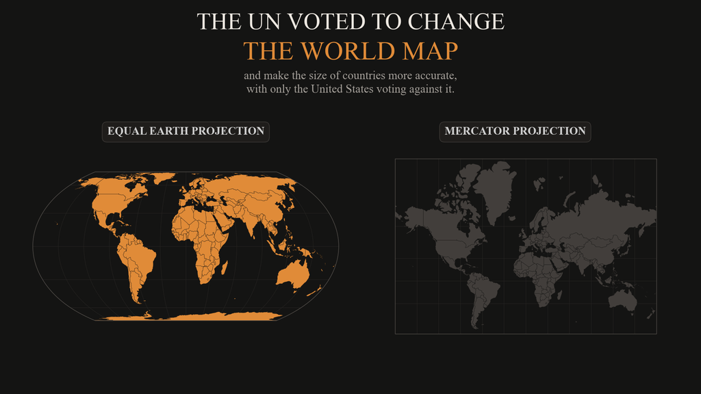

> **Author:** Imtiaj Iqbal Mahfuj

## 📝 Overview

The standard Mercator projection (EPSG:3395), designed in 1569 for nautical navigation, preserves local conformal shapes and rhumb lines at the expense of extreme areal distortion toward the poles. This creates significant misrepresentations of landmasses, vastly exaggerating regions like Greenland, North America, and Eurasia relative to equatorial continents such as Africa and South America. The Equal Earth projection (EPSG:8857), created in 2018 and formally adopted by international organizations including the United Nations, addresses this distortion by providing an equal-area, visually balanced representation that accurately preserves relative continent sizes without drastic shape distortion.

This work directly benefits cartographers, urban and regional planners, GIS educators, researchers, and policy analysts who require unbiased global baseline visualizations. By deploying custom Python automated workflows with GeoPandas and Matplotlib, this repository reproduces, benchmarks, and generates high-impact editorial graphics comparing both projections across multiple multi-platform aspect ratios.

## 🛠️ Tools & Technologies

## ⚙️ Methodology

[output not shown]

## Codes👇

```python
import io
import urllib.request
from pathlib import Path

import numpy as np
import geopandas as gpd
import matplotlib.pyplot as plt
from shapely.geometry import LineString, box
```

```python
BG        = "#141413"   # warm obsidian black
MAGENTA   = "#E08B38"   # warm marigold amber — Equal Earth land
CYAN      = "#4EBE9E"   # soft sage green — accent
GREY      = "#423E3B"   # warm taupe grey — Mercator land, muted
GRAT      = "#262422"   # graticule lines
EDGE      = "#524E4A"   # projection border
TEXT      = "#EDE8E1"   # parchment white
MUTED     = "#A39E98"   # muted sand
CHIP_BG   = "#1F1D1B"   # dark warm card background
CHIP_EDGE = "#3B3835"   # card border

# plt.rcParams["font.family"] = ["Times New Roman"]
HEADLINE_FONT = "Times New Roman"

MERCATOR    = "EPSG:3395"   # World Mercator
EQUAL_EARTH = "EPSG:8857"   # Equal Earth Greenwich

DATA = Path("data")
OUT  = Path("output")
DATA.mkdir(exist_ok=True)
OUT.mkdir(exist_ok=True)
```

## 1. Download Natural Earth countries (1:110m)

```python
NE_URLS = [
    "https://naciscdn.org/naturalearth/110m/cultural/ne_110m_admin_0_countries.zip",
    "https://naturalearth.s3.amazonaws.com/110m_cultural/ne_110m_admin_0_countries.zip",
]
ne_zip = DATA / "ne_110m_admin_0_countries.zip"

if not ne_zip.exists():
    for url in NE_URLS:
        try:
            print("downloading", url)
            req = urllib.request.Request(url, headers={"User-Agent": "Mozilla/5.0"})
            ne_zip.write_bytes(urllib.request.urlopen(req, timeout=60).read())
            break
        except Exception as e:
            print("  failed:", e)

world = gpd.read_file(ne_zip)
print(len(world), "countries,", "CRS:", world.crs)
world.head(3)[["NAME", "CONTINENT", "geometry"]]
```

```
177 countries, CRS: EPSG:4326
```

|  | NAME | CONTINENT | geometry |
| --- | --- | --- | --- |
| 0 | Fiji | Oceania | MULTIPOLYGON (((180 -16.06713, 180 -16.55522, ... |
| 1 | Tanzania | Africa | POLYGON ((33.90371 -0.95, 34.07262 -1.05982, 3... |
| 2 | W. Sahara | Africa | POLYGON ((-8.66559 27.65643, -8.66512 27.58948... |

## 2. Prepare the two projections

```python
# Equal Earth: everything
world_ee = world.to_crs(EQUAL_EARTH)

# Mercator: clip out the poles / Antarctica first (in lon-lat), then project
world_merc = gpd.clip(world, box(-180, -59, 180, 84)).to_crs(MERCATOR)


def graticule(lon_step=30, lat_step=30, lat_min=-90, lat_max=90):
    """Graticule as a lon/lat GeoSeries, densified so it curves when projected."""
    lines = []
    lats = np.linspace(lat_min, lat_max, 181)
    for lon in range(-180, 181, lon_step):
        lines.append(LineString(np.column_stack([np.full_like(lats, float(lon)), lats])))
    lons = np.linspace(-180, 180, 361)
    for lat in range(-90, 91, lat_step):
        if lat_min <= lat <= lat_max:
            lines.append(LineString(np.column_stack([lons, np.full_like(lons, float(lat))])))
    return gpd.GeoSeries(lines, crs=4326)


def world_outline():
    """Outline of the whole globe (becomes the curved Equal Earth border)."""
    top    = [(x,  90.0) for x in np.linspace(-180, 180, 361)]
    right  = [(180.0,  y) for y in np.linspace(90, -90, 181)]
    bottom = [(x, -90.0) for x in np.linspace(180, -180, 361)]
    left   = [(-180.0, y) for y in np.linspace(-90, 90, 181)]
    return gpd.GeoSeries([LineString(top + right + bottom + left)], crs=4326)


grat_ee    = graticule().to_crs(EQUAL_EARTH)
border_ee  = world_outline().to_crs(EQUAL_EARTH)
grat_merc  = graticule(lat_min=-59, lat_max=84).to_crs(MERCATOR)
border_merc = gpd.GeoSeries([box(-180, -59, 180, 84).boundary], crs=4326).to_crs(MERCATOR)


def draw_map(ax, land, grat, border, land_color):
    grat.plot(ax=ax, color=GRAT, linewidth=0.7, zorder=1)
    land.plot(ax=ax, color=land_color, edgecolor=BG, linewidth=0.35, zorder=2)
    border.plot(ax=ax, color=EDGE, linewidth=1.0, zorder=3)
    ax.set_aspect("equal")
    ax.axis("off")


def chip(fig, x, y, text, size=20, ha="left"):
    fig.text(x, y, text, fontsize=size, fontweight="bold", color="#CFCFCF",
             ha=ha, va="center",
             bbox=dict(boxstyle="round,pad=0.45", facecolor=CHIP_BG,
                       edgecolor=CHIP_EDGE, linewidth=1.2))


def headline(fig, y1, y2, size, x=0.5):
    fig.text(x, y1, "THE UN VOTED TO CHANGE", fontsize=size, fontfamily=HEADLINE_FONT,
             color=TEXT, ha="center", va="center")
    fig.text(x, y2, "THE WORLD MAP", fontsize=size * 1.12, fontfamily=HEADLINE_FONT,
             color=MAGENTA, ha="center", va="center")


# VOTE = "164 in favour  \u00b7  6 abstentions  \u00b7  1 against \u2014 the United States"
# CREDIT = "Data: Natural Earth"
```

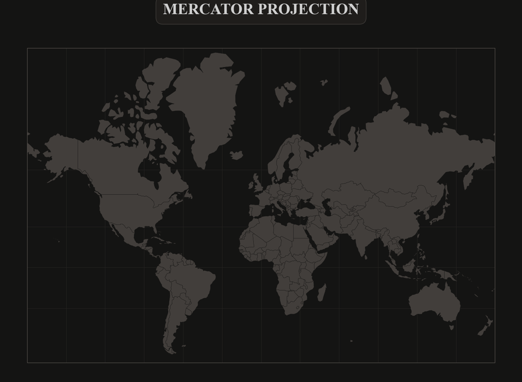

```python
fig = plt.figure(figsize=(19.2, 10.8), dpi=100, facecolor=BG)
ax = fig.add_axes([0.03, 0.03, 0.94, 0.86])
draw_map(ax, world_merc, grat_merc, border_merc, GREY)
chip(fig, 0.5, 0.945, "MERCATOR PROJECTION", size=30, ha="center")
fig.savefig(OUT / "map_mercator_1920x1080.png", dpi=100, facecolor=BG)
plt.show()
```

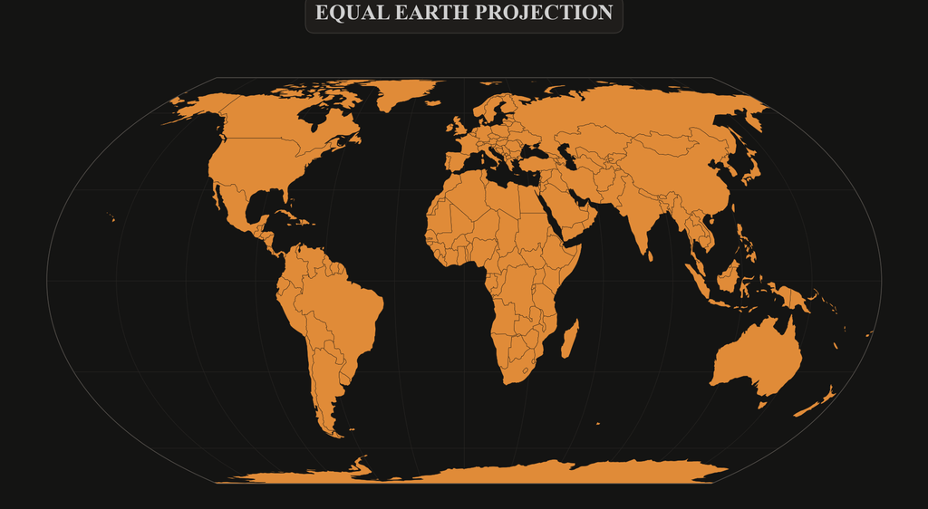

```python
fig = plt.figure(figsize=(19.2, 10.8), dpi=100, facecolor=BG)
ax = fig.add_axes([0.03, 0.03, 0.94, 0.86])
draw_map(ax, world_ee, grat_ee, border_ee, MAGENTA)
chip(fig, 0.5, 0.945, "EQUAL EARTH PROJECTION", size=30, ha="center")
fig.savefig(OUT / "map_equal_earth_1920x1080.png", dpi=100, facecolor=BG)
plt.show()
```

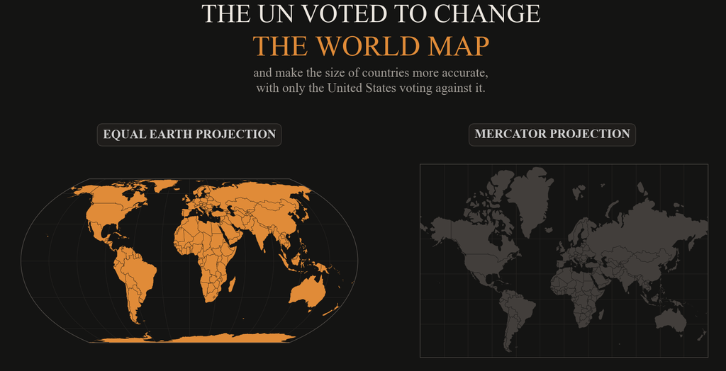

```python
fig = plt.figure(figsize=(19.2, 10.8), dpi=100, facecolor=BG)

headline(fig, 0.94, 0.865, size=46)
fig.text(0.5, 0.79, "and make the size of countries more accurate,\n"
                    "with only the United States voting against it.",
         fontsize=23, color=MUTED, ha="center", va="center", linespacing=1.35)

chip(fig, 0.265, 0.665, "EQUAL EARTH PROJECTION", size=22, ha="center")
ax1 = fig.add_axes([0.025, 0.115, 0.48, 0.52])
draw_map(ax1, world_ee, grat_ee, border_ee, MAGENTA)

chip(fig, 0.735, 0.665, "MERCATOR PROJECTION", size=22, ha="center")
ax2 = fig.add_axes([0.545, 0.115, 0.41, 0.52])
draw_map(ax2, world_merc, grat_merc, border_merc, GREY)

# fig.text(0.5, 0.045, VOTE, fontsize=19, color=TEXT, ha="center", fontweight="bold")
# fig.text(0.985, 0.015, CREDIT, fontsize=11, color="#6E6E6E", ha="right")

fig.savefig(OUT / "un_world_map_yt_1920x1080.png", dpi=100, facecolor=BG)
plt.show()
```

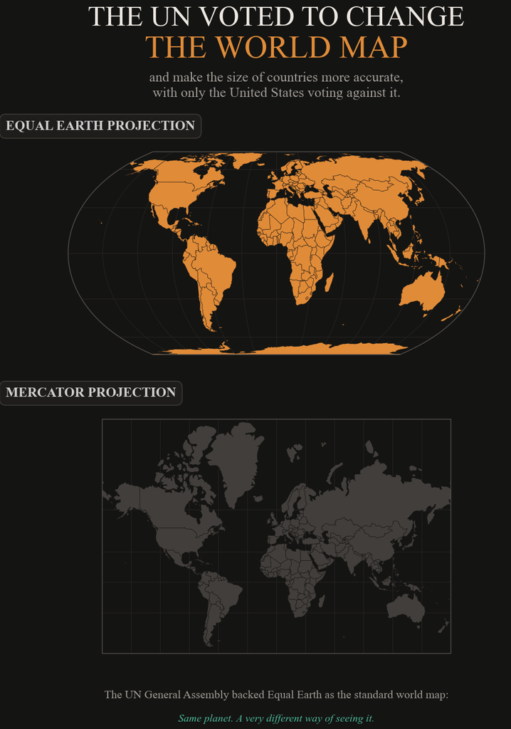

```python
fig = plt.figure(figsize=(10.8, 13.5), dpi=100, facecolor=BG)

headline(fig, 0.955, 0.915, size=36)
fig.text(0.5, 0.868, "and make the size of countries more accurate,\n"
                     "with only the United States voting against it.",
         fontsize=17.5, color=MUTED, ha="center", va="center", linespacing=1.35)

chip(fig, 0.06, 0.815, "EQUAL EARTH PROJECTION", size=17)
ax1 = fig.add_axes([0.035, 0.505, 0.93, 0.29])
draw_map(ax1, world_ee, grat_ee, border_ee, MAGENTA)

chip(fig, 0.06, 0.468, "MERCATOR PROJECTION", size=17)
ax2 = fig.add_axes([0.10, 0.115, 0.80, 0.335])
draw_map(ax2, world_merc, grat_merc, border_merc, GREY)

fig.text(0.5, 0.072, "The UN General Assembly backed Equal Earth as the standard world map:",
         fontsize=14.5, color=MUTED, ha="center")
# fig.text(0.5, 0.049, VOTE, fontsize=15.5, color=TEXT, ha="center", fontweight="bold")
fig.text(0.5, 0.042, "Same planet. A very different way of seeing it.",
         fontsize=13.5, color=CYAN, ha="center", style="italic")
# fig.text(0.985, 0.006, CREDIT, fontsize=9, color="#6E6E6E", ha="right")

fig.savefig(OUT / "un_world_map_linkedin_1080x1350.png", dpi=100, facecolor=BG)
plt.show()
```

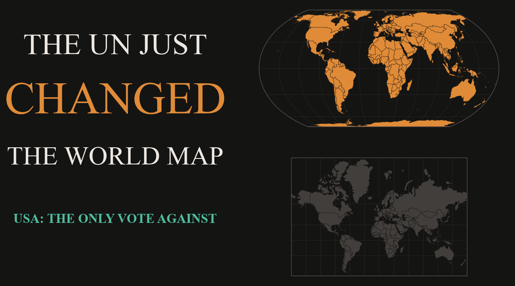

```python
fig = plt.figure(figsize=(12.8, 7.2), dpi=100, facecolor=BG)

fig.text(0.26, 0.80, "THE UN JUST", fontsize=50, fontfamily=HEADLINE_FONT,
         color=TEXT, ha="center", va="center")
fig.text(0.26, 0.62, "CHANGED", fontsize=76, fontfamily=HEADLINE_FONT,
         color=MAGENTA, ha="center", va="center")
fig.text(0.26, 0.44, "THE WORLD MAP", fontsize=44, fontfamily=HEADLINE_FONT,
         color=TEXT, ha="center", va="center")
fig.text(0.26, 0.24, "USA: THE ONLY VOTE AGAINST", fontsize=22, fontweight="bold",
         color=CYAN, ha="center", va="center")

ax1 = fig.add_axes([0.50, 0.50, 0.48, 0.46])
draw_map(ax1, world_ee, grat_ee, border_ee, MAGENTA)
ax2 = fig.add_axes([0.54, 0.04, 0.40, 0.42])
draw_map(ax2, world_merc, grat_merc, border_merc, GREY)

fig.savefig(OUT / "un_world_map_thumb_1280x720.png", dpi=100, facecolor=BG)
plt.show()
```

```python
from PIL import Image

for p in sorted(OUT.glob("*.png")):
    print(f"{p.name:45s} {Image.open(p).size}")
```

```
map_equal_earth_1920x1080.png                 (1920, 1080)
map_mercator_1920x1080.png                    (1920, 1080)
un_world_map_linkedin_1080x1350.png           (1080, 1350)
un_world_map_thumb_1280x720.png               (1280, 720)
un_world_map_yt_1920x1080.png                 (1920, 1080)
```

## 📊 Results & Insights

- 🔹 **True Continental Scale:** In the Equal Earth projection, Africa's true land area (~30.37 million km²) is faithfully represented as roughly 14 times larger than Greenland (~2.16 million km²), dispelling the visual parity falsely suggested by Mercator maps.
- 🔹 **Boundary and Polar Behavior:** Mercator maps inherently fail at extreme latitudes, requiring artificial truncation at ~84°N and ~59°S, whereas Equal Earth encapsulates the entire globe and polar caps seamlessly within a curved pseudocylindrical bounding perimeter.
- 🔹 **Editorial Cartography Benchmarks:** Successfully exported automated layouts across 16:9 desktop presentations, 4:5 vertical LinkedIn feeds, and YouTube 720p thumbnails without manual graphic design intervention.

## ❓ Why this project?

- Addresses the persistent public misconception of global landmass sizes caused by centuries of overreliance on conformal Mercator wall maps.
- Bridges the gap between programmatic GIS pipelines and high-end visual journalism, demonstrating that publication-quality cartographic infographics can be completely automated with open-source Python libraries.
- Supports ethical and objective cartographic standards in line with international bodies such as the UN and academic research institutions.

## 📎 Links

- 🔗 [See more in LinkedIn](https://www.linkedin.com/in/imtiajiqbalmahfuj)

## 🔖 Tags

`GIS` `Remote Sensing` `Geospatial Python` `Python` `GEE` `Spatial Data-Science` `Equal Earth` `Cartography` `Map Projections`

## 📌 Credits & Shoutouts

- 👨‍💻 **Author:** [Imtiaj Iqbal Mahfuj](https://imtiajiqbalmahfuj.github.io/)
- 🙌 **Inspiration:** Special thanks to **Milan Janosov** for his creative tutorial, geospatial insights, and cartographic styling inspiration ([Watch Tutorial](https://youtu.be/xft_KurHuKw?si=R7GIhWmdodgnMO1T)).
- 🗂️ **Data Sources:** Natural Earth (Free vector and raster map data @ naturalearthdata.com)

## 💬 Connect with Me

📧 Email: imtiajiqbal.ruet@gmail.com  
🌐 Portfolio: https://imtiajiqbalmahfuj.github.io/